# R 入门笔记 基于薛毅中文教程

熊康

2019-05-04

# 1 第一部分：R安装及其初识

## 1.1 R GUI及Rstudio的安装

R 软件是全免费的，下载网站：

https://cran.r-project.org

一般来讲，用户操作更多的是Rstudio而不是R GUI，而Rstudio的应用必须以安装了R GUI为基础，Rstudio的下载网站：

https://www.rstudio.com/products/rstudio/download/

**注意事项:** 无论是R GUI还是Rstudio，其安装路径不要有中文，否则会很麻烦。如果已经有中文的话，只能通过“以管理员身份运行”,如果还是不行，放弃吧！

## 1.2 R的基础功能

R的基础功能，可以把它当做计算器，例如现在还不知道电脑计算功能怎么用的我。当然，也可以当做统计软件。对于R和其他统计软件的比较，百度一下就知道了。

尝试一下计算器的威力：

```r
# 计算体重
# 输入体重数据
X1 <- c(35,40,40,42,37,45,43,37,44,42,41,39)
mean(X1)  # 计算体重的均值
```

```
## [1] 40.41667
```

```r
sd(X1)    # 计算体重的标准差
```

```
## [1] 3.028901
```

上述是普通计算器都可以完成的 现在来一个统计软件的：

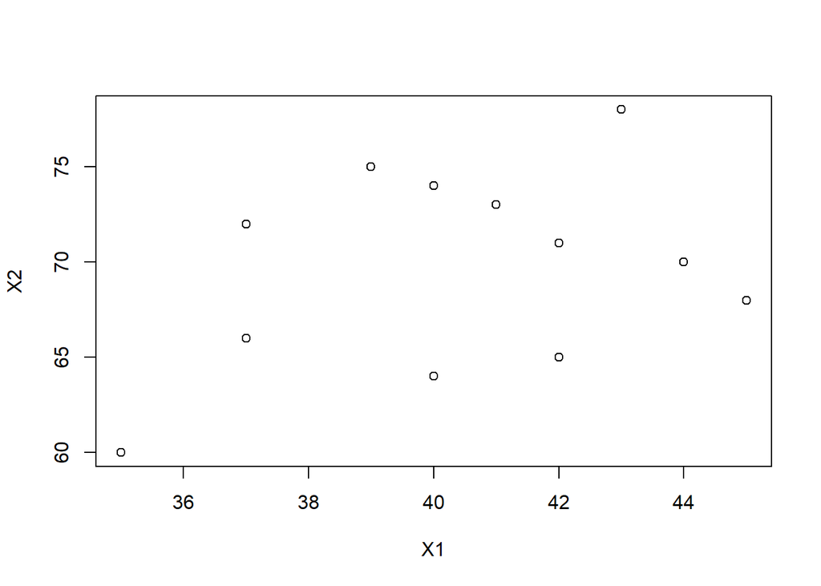

```r
X1<-c(35,40,40,42,37,45,43,37,44,42,41,39)
X2<-c(60,74,64,71,72,68,78,66,70,65,73,75)
plot(X1,X2)
```

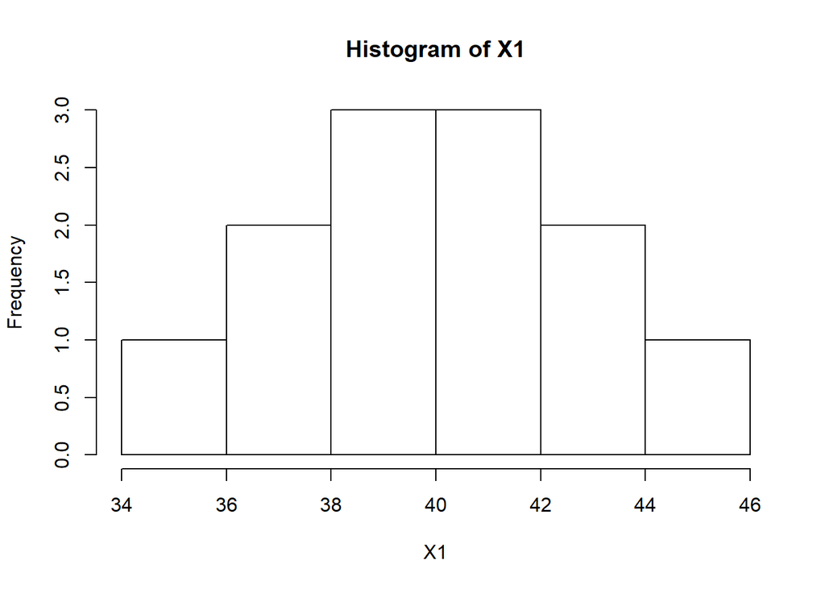

```r
hist(X1)
```

上述两个例子均是手动输入的数据。一般来讲，手动输入数据是不存在的，那么怎么读取数据呢？File > Import Dataset,说实话，我很少导入数据库的数据。基本上都是读取CSV格式的数据，读入之后存为数据框文件（R的数据结构在后面会涉及）。 如何读取CSV格式的文件，以硕士课程：数据挖掘课上的演示数据集heart为例：

```r
# 读取CSV文件，将数据集命名为data.heart
data.heart <- read.csv(file.choose())  #该函数默认Header = TRUE
# 查看数据集
str(data.heart)
```

```
## 'data.frame':    303 obs. of  14 variables:
##  $ age     : int  63 37 41 56 57 57 56 44 52 57 ...
##  $ sex     : int  1 1 0 1 0 1 0 1 1 1 ...
##  $ cp      : int  3 2 1 1 0 0 1 1 2 2 ...
##  $ trestbps: int  145 130 130 120 120 140 140 120 172 150 ...
##  $ chol    : int  233 250 204 236 354 192 294 263 199 168 ...
##  $ fbs     : int  1 0 0 0 0 0 0 0 1 0 ...
##  $ restecg : int  0 1 0 1 1 1 0 1 1 1 ...
##  $ thalach : int  150 187 172 178 163 148 153 173 162 174 ...
##  $ exang   : int  0 0 0 0 1 0 0 0 0 0 ...
##  $ oldpeak : num  2.3 3.5 1.4 0.8 0.6 0.4 1.3 0 0.5 1.6 ...
##  $ slope   : int  0 0 2 2 2 1 1 2 2 2 ...
##  $ ca      : int  0 0 0 0 0 0 0 0 0 0 ...
##  $ thal    : int  1 2 2 2 2 1 2 3 3 2 ...
##  $ target  : int  1 1 1 1 1 1 1 1 1 1 ...
```

```r
# 浏览变量
summary(data.heart)
```

```
##       age             sex               cp           trestbps
##  Min.   :29.00   Min.   :0.0000   Min.   :0.000   Min.   : 94.0
##  1st Qu.:47.50   1st Qu.:0.0000   1st Qu.:0.000   1st Qu.:120.0
##  Median :55.00   Median :1.0000   Median :1.000   Median :130.0
##  Mean   :54.37   Mean   :0.6832   Mean   :0.967   Mean   :131.6
##  3rd Qu.:61.00   3rd Qu.:1.0000   3rd Qu.:2.000   3rd Qu.:140.0
##  Max.   :77.00   Max.   :1.0000   Max.   :3.000   Max.   :200.0
##       chol            fbs            restecg          thalach
##  Min.   :126.0   Min.   :0.0000   Min.   :0.0000   Min.   : 71.0
##  1st Qu.:211.0   1st Qu.:0.0000   1st Qu.:0.0000   1st Qu.:133.5
##  Median :240.0   Median :0.0000   Median :1.0000   Median :153.0
##  Mean   :246.3   Mean   :0.1485   Mean   :0.5281   Mean   :149.6
##  3rd Qu.:274.5   3rd Qu.:0.0000   3rd Qu.:1.0000   3rd Qu.:166.0
##  Max.   :564.0   Max.   :1.0000   Max.   :2.0000   Max.   :202.0
##      exang           oldpeak         slope             ca
##  Min.   :0.0000   Min.   :0.00   Min.   :0.000   Min.   :0.0000
##  1st Qu.:0.0000   1st Qu.:0.00   1st Qu.:1.000   1st Qu.:0.0000
##  Median :0.0000   Median :0.80   Median :1.000   Median :0.0000
##  Mean   :0.3267   Mean   :1.04   Mean   :1.399   Mean   :0.7294
##  3rd Qu.:1.0000   3rd Qu.:1.60   3rd Qu.:2.000   3rd Qu.:1.0000
##  Max.   :1.0000   Max.   :6.20   Max.   :2.000   Max.   :4.0000
##       thal           target
##  Min.   :0.000   Min.   :0.0000
##  1st Qu.:2.000   1st Qu.:0.0000
##  Median :2.000   Median :1.0000
##  Mean   :2.314   Mean   :0.5446
##  3rd Qu.:3.000   3rd Qu.:1.0000
##  Max.   :3.000   Max.   :1.0000
```

# 2 数据结构

## 2.1 向量

R 的数据结构和其他编程软件的数据结构比较类似，包括向量、数组、矩阵、列表、数据框等等。 与向量相关的操作包括赋值、运算和函数

```r
#  向量赋值
X <- c(10.4,5.6,3.1,6.4,21.7)  #将"10.4,5.6,3.1,6.4,21.7"赋值给X
assign("x",c(10.4,5.6,3.1,6.4,21.7)) # 或者使用assign()
y <- c(X,0,X)
X
```

```
## [1] 10.4  5.6  3.1  6.4 21.7
```

```r
x
```

```
## [1] 10.4  5.6  3.1  6.4 21.7
```

```r
y
```

```
##  [1] 10.4  5.6  3.1  6.4 21.7  0.0 10.4  5.6  3.1  6.4 21.7
```

```r
#  向量运算
x <- c(-1,0,2)
y <- c(3,8,2)
v <- 2*x + y + 1
v
```

```
## [1] 2 9 7
```

```r
x *  y
```

```
## [1] -3  0  4
```

```r
x / y
```

```
## [1] -0.3333333  0.0000000  1.0000000
```

```r
y^x
```

```
## [1] 0.3333333 1.0000000 4.0000000
```

```r
exp(x)
```

```
## [1] 0.3678794 1.0000000 7.3890561
```

```r
sqrt(y)
```

```
## [1] 1.732051 2.828427 1.414214
```

```r
#  与向量运算有关的函数
x <- c(10,6,4,7,8)
min(x)
```

```
## [1] 4
```

```r
max(x)
```

```
## [1] 10
```

```r
range(x)
```

```
## [1]  4 10
```

```r
which.min(x)
```

```
## [1] 3
```

```r
which.max(x)
```

```
## [1] 1
```

```r
#  等差数列、等间隔函数、重复函数、逻辑向量
##  等差数列
2.312:6
```

```
## [1] 2.312 3.312 4.312 5.312
```

```r
4:7.6
```

```
## [1] 4 5 6 7
```

```r
n <- 5
1:(n-1)
```

```
## [1] 1 2 3 4
```

```r
##  等间隔函数
##  seq(from=value1,to=value2,by=value3)
seq(-5,5,by=0.2)
```

```
##  [1] -5.0 -4.8 -4.6 -4.4 -4.2 -4.0 -3.8 -3.6 -3.4 -3.2 -3.0 -2.8 -2.6 -2.4
## [15] -2.2 -2.0 -1.8 -1.6 -1.4 -1.2 -1.0 -0.8 -0.6 -0.4 -0.2  0.0  0.2  0.4
## [29]  0.6  0.8  1.0  1.2  1.4  1.6  1.8  2.0  2.2  2.4  2.6  2.8  3.0  3.2
## [43]  3.4  3.6  3.8  4.0  4.2  4.4  4.6  4.8  5.0
```

```r
##  seq(length=value2,from=value1,by=value3)
s2 <- seq(length=51,from=-5,by=0.2)
##  重复函数
s <- rep(x,times = 3)
x <- c(1,4,6.25)
x
```

```
## [1] 1.00 4.00 6.25
```

```r
s <- rep(x,times = 3)
s
```

```
## [1] 1.00 4.00 6.25 1.00 4.00 6.25 1.00 4.00 6.25
```

```r
##  逻辑向量
x <- 1:7
M <- x > 3 #  逻辑运算符有<.<=,>,>=，==(表示等于),！=(表示是否等于)。如果c1和c2是两个逻辑表达式，则c1&c2表示c1"与"c2,c1｜c2 表示c1"或"c2,!c1表示"非c1".
M
```

```
## [1] FALSE FALSE FALSE  TRUE  TRUE  TRUE  TRUE
```

```r
#  字符型向量
y <- c("er","sdf","eir","jk","dim")
y
```

```
## [1] "er"  "sdf" "eir" "jk"  "dim"
```

```r
paste("My","Job")  #用paste函数将自变量连接成一个字符串，中间用空格分开
```

```
## [1] "My Job"
```

```r
paste("My","Job",sep = "")
```

```
## [1] "MyJob"
```

```r
paste("X",1:6,sep="")
```

```
## [1] "X1" "X2" "X3" "X4" "X5" "X6"
```

```r
##  关于paste函数，还有以下几种用法：
paste(1:10)  #  same as as.character(1:10)
```

```
##  [1] "1"  "2"  "3"  "4"  "5"  "6"  "7"  "8"  "9"  "10"
```

```r
paste("Today is",date())
```

```
## [1] "Today is Sat May 04 16:00:32 2019"
```

```r
paste(c("a","b"),collapse = ".")
```

```
## [1] "a.b"
```

## 2.2 数组和矩阵

```r
# 将向量定义为数组，向量只有定义了维数向量（dim属性）后才能被看作是数组
z <- 1:12
dim(z) <- c(3,4)
z
```

```
##      [,1] [,2] [,3] [,4]
## [1,]    1    4    7   10
## [2,]    2    5    8   11
## [3,]    3    6    9   12
```

```r
# array()函数生成数组，其结构形式为 array(data = NA，dim = length(data),dimnames = NULL)
X <- array(1:20,dim = c(4,5))
X
```

```
##      [,1] [,2] [,3] [,4] [,5]
## [1,]    1    5    9   13   17
## [2,]    2    6   10   14   18
## [3,]    3    7   11   15   19
## [4,]    4    8   12   16   20
```

```r
# 用matrix()函数构造矩阵,★matrix()默认按列排列
A <- matrix(1:15,nrow = 3,ncol = 5,byrow = TRUE)
A
```

```
##      [,1] [,2] [,3] [,4] [,5]
## [1,]    1    2    3    4    5
## [2,]    6    7    8    9   10
## [3,]   11   12   13   14   15
```

```r
# 矩阵运算
##  转置运算
A <- matrix(1:6,nrow = 2)
A
```

```
##      [,1] [,2] [,3]
## [1,]    1    3    5
## [2,]    2    4    6
```

```r
t(A) # t()函数用于矩阵的转置
```

```
##      [,1] [,2]
## [1,]    1    2
## [2,]    3    4
## [3,]    5    6
```

## 2.3 数据框

一般来讲，CSV读入的数据都是数据框类型。数据框与矩阵的区别在于数据框只要求列内数据类型相同，而矩阵要求所有数据均未数字型？整数。

```r
#生成数据框的函数为data.frame(),函数内赋值用"=",不可用"<-"
df <- data.frame(
  Name = c ("Alice","Becka","James","Jeffrey","John"),
  Sex = c ("F", "F", "M", "M", "M"),
  Age = c(13,13,12,13,12),
  Height = c(56.5,65.3,57.3,62.5,59.0),
  Weight = c(84.0,98.0,83.0,84.0,99.5)
  )
df
```

```
##      Name Sex Age Height Weight
## 1   Alice   F  13   56.5   84.0
## 2   Becka   F  13   65.3   98.0
## 3   James   M  12   57.3   83.0
## 4 Jeffrey   M  13   62.5   84.0
## 5    John   M  12   59.0   99.5
```

```r
# 数据框引用
df[1:2,3:5]
```

```
##   Age Height Weight
## 1  13   56.5     84
## 2  13   65.3     98
```

```r
df[["Height"]]
```

```
## [1] 56.5 65.3 57.3 62.5 59.0
```

```r
df$Height  #用[["Height"]]或者$进行引用均可以
```

```
## [1] 56.5 65.3 57.3 62.5 59.0
```

```r
#  数据框命名
names(df)
```

```
## [1] "Name"   "Sex"    "Age"    "Height" "Weight"
```

```r
rownames(df) <- c("one","two","three","four","five")
df
```

```
##          Name Sex Age Height Weight
## one     Alice   F  13   56.5   84.0
## two     Becka   F  13   65.3   98.0
## three   James   M  12   57.3   83.0
## four  Jeffrey   M  13   62.5   84.0
## five     John   M  12   59.0   99.5
```